# Analysis of Multiple-Outcomes Scenario (Study 2)

Dennis W. H. Teo and Zheng Yong Ang

# 1 Participant Exclusion

> Number of flat responders:

```r
# number of flat responders
sum(ecl_dat$flat)
```

```
## [1] 0
```

```r
# remove flat responders
ecl_dat <- ecl_dat[!ecl_dat$flat, ]
```

> Number of participants who failed first attention check:

```r
# number of px who failed attention1
sum(ecl_dat$attention1 != 2)
```

```
## [1] 9
```

```r
# remove those who failed attention1 check
ecl_dat <- ecl_dat[ecl_dat$attention1=="2",]
```

> Number of participants who failed second attention check:

```r
# number who failed attention2 check
sum(!(ecl_dat$attentionBulb1 == 0 & ecl_dat$attentionBulb2 == 1) )
```

```
## [1] 11
```

```r
pass_attention2 <- (ecl_dat$attentionBulb1 == 0 & ecl_dat$attentionBulb2 == 1)

# remove those who failed attention2 check
ecl_dat <- ecl_dat[pass_attention2, ]
```

> Number of outliers for total time taken:

```r
# outlier for total time taken to complete survey
rt_range <- 3*sd(ecl_dat$totalRT)
slow <- which(ecl_dat$totalRT > mean(ecl_dat$totalRT,na.rm = T) + rt_range)
fast <- which(ecl_dat$totalRT < mean(ecl_dat$totalRT,na.rm = T) - rt_range)

# number of outliers
length(slow)
```

```
## [1] 2
```

```r
length(fast)
```

```
## [1] 0
```

```r
# remove outliers
ecl_dat <- ecl_dat[-slow,]
```

> Number of participants who failed anti-bot verification:

```r
n_fails <- which(ecl_dat$nFails > 3)
# number who failed bot check (more than 3 times)
length(n_fails)
```

```
## [1] 0
```

> Number of remaining participants after data cleaning:

```r
# number of participants in each condition (after exclusions)
ecl_dat$condition <- relabel(ecl_dat$condition,
                             from = c("condition 1", "condition 2"),
                             to = c("emotion", "no-emotion"))
table(ecl_dat$condition)
```

```
##
##    emotion no-emotion
##         68         57
```

# 2 Summary Statistics

- `relationBlueOneNorm`: likelihood of causal relationship between box and bulb 1 (purple)
- `relationBlueTwoNorm`: likelihood of causal relationship between box and bulb 2 (red)
- `exp1Norm`: likelihood that agent expected bulb 1 (purple) to light up
- `exp2Norm`: likelihood that agent expected bulb 2 (red) to light up
- `desire1Norm`: likelihood that agent desires bulb 1 (purple) to light up
- `desire2Norm`: likelihood that agent desires bulb 2 (red) to light up
- `knowledgeNorm`: likelihood that agent has knowledge of the function of the box

```r
# scaling variables
ecl_dat$relationBlueOneNorm <- (ecl_dat$relationBlueOne - 1)/8
ecl_dat$relationBlueTwoNorm <- (ecl_dat$relationBlueTwo - 1)/8
ecl_dat$exp1Norm <- (ecl_dat$exp1 - 1)/8
ecl_dat$exp2Norm <- (ecl_dat$exp2 - 1)/8
ecl_dat$desire1Norm <- (ecl_dat$desire1 - 1)/8
ecl_dat$desire2Norm <- (ecl_dat$desire2 - 1)/8
ecl_dat$knowledgeNorm <- (ecl_dat$knowledge1 - 1)/8

emotion_dat <- ecl_dat %>%
  filter(condition == "emotion")
noemotion_dat <- ecl_dat %>%
  filter(condition == "no-emotion")
```

```r
human_cause_data <- gather.keep(ecl_dat, var.to.gather = c("relationBlueOneNorm", "relationBlueTwoNorm"), keep = c("id", "condition"), key = "structure",value="likelihood")

human_expectation_data <- gather.keep(ecl_dat, var.to.gather = c("exp1Norm","exp2Norm"), keep = c("id", "condition"), key = "structure",value="likelihood")

human_desire_data <- gather.keep(ecl_dat, var.to.gather = c("desire1Norm", "desire2Norm"), keep = c("id", "condition"), key = "structure",value="likelihood")

human_knowledge_data <- gather.keep(ecl_dat, var.to.gather = c("knowledgeNorm"), keep = c("id", "condition"), key = "structure",value="likelihood")
```

```r
set.seed(100)

human_cause <- human_cause_data %>% group_by(condition, structure) %>%
  multi_boot_standard(col="likelihood")

human_expectation <- human_expectation_data %>% group_by(condition, structure) %>%
  multi_boot_standard(col="likelihood")

human_desire <- human_desire_data %>% group_by(condition, structure) %>%
  multi_boot_standard(col="likelihood")

human_knowledge <- human_knowledge_data %>% group_by(condition, structure) %>%
  multi_boot_standard(col="likelihood")
```

```r
key_variables1 <- c("relationBlueOneNorm", "relationBlueTwoNorm", "exp1Norm", "exp2Norm", "desire1Norm", "desire2Norm","knowledgeNorm" )

table1 <- ecl_dat[,key_variables1] %>%
  describe()%>%
  as.data.frame()%>%
  select(n,mean,sd,median,min,max,skew,kurtosis)
knitr::kable(table1)
```

|  | n | mean | sd | median | min | max | skew | kurtosis |
| --- | --- | --- | --- | --- | --- | --- | --- | --- |
| relationBlueOneNorm | 125 | 0.216 | 0.2546820 | 0.125 | 0 | 1 | 1.2414874 | 0.7857722 |
| relationBlueTwoNorm | 125 | 0.904 | 0.1905901 | 1.000 | 0 | 1 | -2.8148438 | 8.2303995 |
| exp1Norm | 125 | 0.588 | 0.3800149 | 0.750 | 0 | 1 | -0.3621834 | -1.4371495 |
| exp2Norm | 125 | 0.497 | 0.3873842 | 0.500 | 0 | 1 | 0.0367550 | -1.5710585 |
| desire1Norm | 125 | 0.651 | 0.3192007 | 0.750 | 0 | 1 | -0.5100639 | -0.9389219 |
| desire2Norm | 125 | 0.470 | 0.3714211 | 0.500 | 0 | 1 | 0.0451269 | -1.4949381 |
| knowledgeNorm | 125 | 0.654 | 0.2429116 | 0.625 | 0 | 1 | -0.3384592 | -0.4220579 |

# 3 Demographics

> Gender of participants:

```r
table(ecl_dat$gender)
```

```
##
## Female   Male
##     51     57
```

> Proportion of females amongst participants:

```r
table(ecl_dat$gender)[[1]]/length(ecl_dat$gender) # prop females
```

```
## [1] 0.408
```

> Mean and SD for age amongst participants:

```r
mean(ecl_dat$age,na.rm = T)
```

```
## [1] 28.11111
```

```r
sd(ecl_dat$age,na.rm = T)
```

```
## [1] 11.0126
```

> Primary language of participants:

```r
table(ecl_dat$language)
```

```
##
##         Afrikaans            Arabic         Bulgarian         Cantonese
##                 1                 1                 1                 1
##           chinese            Danish             Dutch           english
##                 1                 1                 2                 2
##           English           ENGLISH English and Shona           Finnish
##                15                 2                 1                 4
##            French             Greek            Hebrew         hungarian
##                 1                 3                 1                 4
##         Hungarian         Hungaryan              igbo           isiZulu
##                 2                 1                 1                 1
##           IsiZULU           italian           Italian            polish
##                 1                 6                 5                 3
##            Polish          Portugal         Português        portuguese
##                 8                 1                 1                 3
##        Portuguese           sesotho           Sesotho           Slovene
##                24                 1                 1                 2
##         Slovenian           Spanish             Swati           Swedish
##                 1                 6                 1                 1
##            Telugu             Venda
##                 1                 1
```

# 4 Visualizing Participants’ Inferences

## 4.1 Belief Inferences

The bar graphs on the left shows the mean likelihood ratings of participants in the emotion condition, whereas the bar graphs on the right shows the mean likelihood ratings of participants in the no emotion condition. Error bars represent 95% confidence intervals.

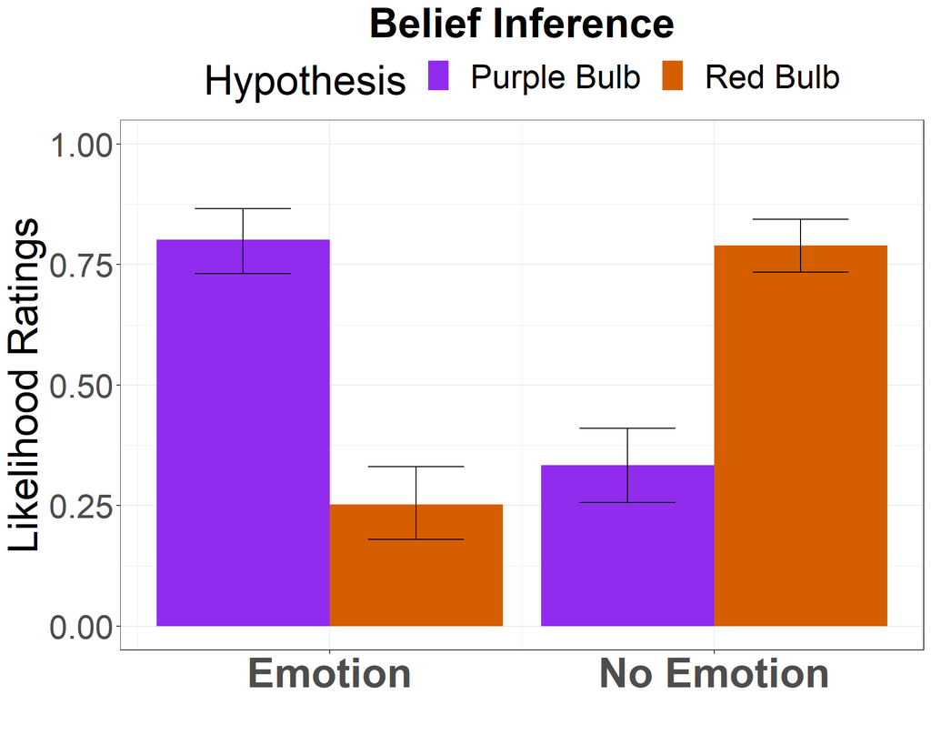

```r
human_expectation$Hypothesis <- factor(human_expectation$structure, labels = c("Purple Bulb", "Red Bulb"), levels = c("exp1Norm","exp2Norm"))

human_expectation$Condition <- as.numeric(relabel(human_expectation$condition,
                                   from = c("emotion","no-emotion"),
                                   to = rev(c(1,2))
                                   ))

breaks <- unique(human_expectation$Condition)

#999999 - grey
#E69F00 - orange
#56B4E9 - light blue
#009E73 - green
#F0E442 - yellow
#0072B2 - dark blue
#D55E00 - red
#CC79A7 - pink

#DB72FB
#C77CFF

colorBlindGrey2   <- c("purple2", "#D55E00")

plot_human_expectation <- ggplot(human_expectation, aes(x = Condition, y = mean, fill = Hypothesis)) +
  geom_bar(stat = "identity", position = "dodge") +
  geom_errorbar( data = human_expectation, aes(x = Condition,ymin=ci_lower, ymax=ci_upper, fill= Hypothesis), position=position_dodge(.9), width = .5, size = .5)+
  ylab("Likelihood Ratings")  +
  ylim(0,1)+
  theme_bw() + xlab("")+
  scale_x_reverse(breaks=breaks, labels=c("Emotion", "No Emotion")) +
  scale_fill_manual(values = colorBlindGrey2) +
  theme(text = element_text(size = 32),
        axis.text.x = element_text(face = "bold", size = 32, hjust = 0.5),
        plot.title = element_text(face = "bold", size = 32, hjust = 0.5),
        legend.position = "top")  +
  ggtitle("Belief Inference")

plot_human_expectation
```

## 4.2 Causal Inferences

The bar graphs on the left shows the mean likelihood ratings of participants in the emotion condition, whereas the bar graphs on the right shows the mean likelihood ratings of participants in the no emotion condition. Error bars represent 95% confidence intervals.

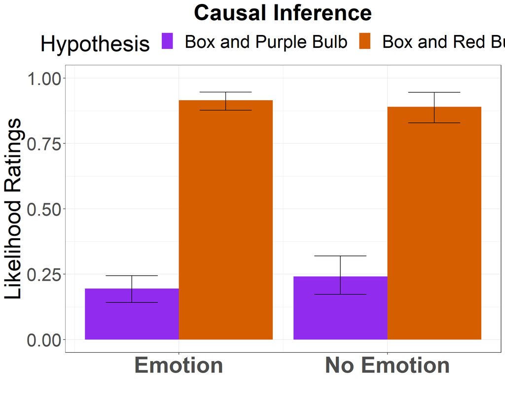

```r
human_cause$Hypothesis <- factor(human_cause$structure, labels = c("Box and Purple Bulb","Box and Red Bulb"), levels = c("relationBlueOneNorm", "relationBlueTwoNorm"))

human_cause$Condition <- as.numeric(relabel(human_cause$condition,
                                   from = c("emotion", "no-emotion"),
                                   to = rev(c(1,2))
                                   ))

breaks <- unique(human_cause$Condition)

#999999 - grey
#E69F00 - orange
#56B4E9 - light blue
#009E73 - green
#F0E442 - yellow
#0072B2 - dark blue
#D55E00 - red
#CC79A7 - pink

colorBlindGrey2   <- c( "purple2", "#D55E00")

plot_human_cause <- ggplot(human_cause, aes(x = Condition, y = mean, fill = Hypothesis)) +
  geom_bar(stat = "identity", position = "dodge") +
  geom_errorbar( data = human_cause, aes(x = Condition,ymin=ci_lower, ymax=ci_upper, fill= Hypothesis), position=position_dodge(.9), width = .5, size = .5)+
  ylab("Likelihood Ratings")  +
  ylim(0,1)+
  theme_bw() + xlab("")+
  scale_x_reverse(breaks=breaks, labels=c( "Emotion", "No Emotion")) +
  scale_fill_manual(values = colorBlindGrey2) +
  theme(text = element_text(size = 32),
        axis.text.x = element_text(face = "bold", size = 32, hjust = 0.5),
        plot.title = element_text(face = "bold", size = 32, hjust = 0.5),
        legend.position = "top")  +
  ggtitle("Causal Inference")

plot_human_cause
```

# 5 Comparing Model Predictions to Human Data

## 5.1 Correlation and Scatterplot

```r
human_cause <- human_cause
human_cause$Subject <- "Human"
human_cause$labels <- c("W","W","W","W")
human_cause$key <- c("w1e","w2e","w1n","w2n")

model_cause <- data.frame(
  condition = c("emotion","emotion","no-emotion","no-emotion"),
  Hypothesis = c("Box and Purple Bulb", "Box and Red Bulb", "Box and Purple Bulb", "Box and Red Bulb"),
  ci_lower_pred = c(0.7049675202481033,0.874081893573677,
                    0.07580605698682724,0.9078706932673027
                    ),
  ci_upper_pred = c(0.7787474304648706,0.9568416524512763,
                    0.19565513576830457,0.977067583179068
                    ),
  mean_pred = c(0.7421171090538607,0.9213143579815191,
                0.13358455761611066,0.9452515734819681
                ),
  Subject = c("Model", "Model","Model", "Model"),
  labels = c("W","W","W","W"),
  key = c("w1e","w2e","w1n","w2n")
)

human_expectation <- human_expectation
human_expectation$Subject <- "Human"
human_expectation$labels <- c("B","B","B","B")
human_expectation$key <- c("b1e","b2e","b1n","b2n")

model_expectation <- data.frame(
  condition = c("emotion","emotion","no-emotion","no-emotion"),
  Hypothesis = c("Purple Bulb", "Red Bulb", "Purple Bulb", "Red Bulb"),
  ci_lower_pred = c(0.7043037054656857,0.8774809092293568,
                    0.07231250783036683,0.9050043642878428
                    ),
  ci_upper_pred = c(0.7761742748150937,0.9596964956037123,
                    0.1997513614994956,0.9760613002504807
                    ),
  mean_pred = c(0.7421171090538607,0.9213143579815191,
                0.13358455761611066,0.9452515734819681
                ),
  Subject = c("Model", "Model","Model", "Model"),
  labels = c("B","B","B","B"),
  key = c("b1e","b2e","b1n","b2n")
)

human_desire$Subject <- "Human"
human_desire$labels <- c("D", "D","D", "D")
human_desire$key <- c("d1e","d2e","d1n","d2n")

model_desire <- data.frame(
  condition = c("emotion", "emotion", "no-emotion","no-emotion"),
  Hypothesis = c("Purple Bulb", "Red Bulb", "Purple Bulb", "Red Bulb"),
  ci_lower_pred = c(0.832, 0.002,
                    0.098, 0.825),
  ci_upper_pred = c(0.875   , 0.01,
                    0.137   , 0.869),
  mean_pred = c( 8.5175e-01, 5.5000e-03,
                 0.11775,  0.84625
                 ),
  Subject = c("Model", "Model","Model", "Model"),
  labels = c("D", "D","D", "D"),
  key = c("d1e","d2e","d1n","d2n")
)

human_variable_data <- human_cause %>%
  full_join(human_expectation)%>%
  full_join(human_desire)

model_variable_data <- model_cause %>%
  full_join(model_expectation)%>%
  full_join(model_desire)

all_variable_data <- full_join(human_variable_data, model_variable_data, by = c("key","labels","condition"))

all_variable_data$Condition <-factor(all_variable_data$condition,
                                     levels=c("emotion","no-emotion"),
                                     labels = c("Emotion","No Emotion"))
```

```r
cor.test(all_variable_data$mean, all_variable_data$mean_pred)
```

```
##
##  Pearson's product-moment correlation
##
## data:  all_variable_data$mean and all_variable_data$mean_pred
## t = 2.6743, df = 10, p-value = 0.02332
## alternative hypothesis: true correlation is not equal to 0
## 95 percent confidence interval:
##  0.1141273 0.8898634
## sample estimates:
##       cor
## 0.6457347
```

```r
human_variable_data <- human_cause %>%
  full_join(human_expectation)

model_variable_data <- model_cause %>%
  full_join(model_expectation)

all_variable_data <- full_join(human_variable_data, model_variable_data, by = c("key","Hypothesis","labels","condition"))

all_variable_data$Condition <-factor(all_variable_data$condition,
                                     levels=c("emotion","no-emotion"),
                                     labels = c("Emotion","No Emotion"))

cor.test(all_variable_data$mean, all_variable_data$mean_pred)
```

```
##
##  Pearson's product-moment correlation
##
## data:  all_variable_data$mean and all_variable_data$mean_pred
## t = 1.6957, df = 6, p-value = 0.1409
## alternative hypothesis: true correlation is not equal to 0
## 95 percent confidence interval:
##  -0.2262262  0.9091907
## sample estimates:
##       cor
## 0.5691833
```

[figure not shown]

```r
corplot2 <- ggplot(all_variable_data, aes(x = mean_pred, y = mean, color = Condition, shape = Condition))+
  geom_point(size=3.5) +
  geom_errorbar(data = all_variable_data, aes(x = mean_pred, ymin=ci_lower, ymax=ci_upper), width = .04, size = .4)+
  geom_errorbarh(data = all_variable_data, aes(y = mean, xmin=ci_lower_pred, xmax=ci_upper_pred), height = .04, size = .4)+
  geom_abline(intercept = 0, slope = 1,linetype = 2) +
  xlim(0, 1.05) +
  ylim(0,1.05)+
  coord_fixed(ratio = 1)+
  ylab("Human Ratings")+
  xlab("Model Predictions")+
  #geom_text(aes(label = paste0(labels)), nudge_x = -0.02, nudge_y = 0.02, show.legend = FALSE, size =4) +
  ggtitle("Multiple-Outcomes (Study 2)")+
  theme_bw()+
    theme(text = element_text(size = 32),
        plot.title = element_text(face = "bold", size = 32, hjust = 0.5)) +
  annotate("text", x=.25, y=.6, label= "r = .92", size = 6)

corplot2
```

## 5.2 Bar Graphs Comparing Belief and Causal Inferences

```r
model_expectation$Hypothesis <- factor(model_expectation$Hypothesis, labels = c("Purple Bulb", "Red Bulb"), levels = c("Purple Bulb", "Red Bulb"))

model_expectation$Condition <- as.numeric(relabel(model_expectation$condition,
                                   from = c("emotion","no-emotion"),
                                   to = rev(c(1,2))
                                   ))

breaks <- unique(model_expectation$Condition)

#999999 - grey
#E69F00 - orange
#56B4E9 - light blue
#009E73 - green
#F0E442 - yellow
#0072B2 - dark blue
#D55E00 - red
#CC79A7 - pink

colorBlindGrey2   <- c("purple2", "#D55E00")

plot_model_expectation <- ggplot(model_expectation, aes(x = Condition, y = mean_pred, fill = Hypothesis)) +
  geom_bar(stat = "identity", position = "dodge") +
  geom_errorbar( data = model_expectation, aes(x = Condition,ymin=ci_lower_pred, ymax=ci_upper_pred, fill= Hypothesis), position=position_dodge(.9), width = .5, size = .5)+
  ylab("Likelihood Ratings")  +
  ylim(0,1)+
  theme_bw() + xlab("")+
  scale_x_reverse(breaks=breaks, labels=c("Emotion", "No Emotion")) +
  scale_fill_manual(values = colorBlindGrey2) +
  theme(text = element_text(size = 32),
        axis.text.x = element_text(face = "bold", size = 32, hjust = 0.5),
        plot.title = element_text(face = "bold", size = 32, hjust = 0.5),
        legend.position = "top")  +
  ggtitle("Belief Inference")
```

The bar graphs below compares our model’s predictions on causal and belief inference against participants’ mean ratings. The error bars represent 95% confidence intervals. Participants’ ratings are shown as the top row of bar graphs, whereas our model’s predictions are illustrated on the bottom row.

```r
model_cause$Hypothesis <- factor(model_cause$Hypothesis, labels = c("Box and Purple Bulb","Box and Red Bulb"), levels = c("Box and Purple Bulb","Box and Red Bulb"))

model_cause$Condition <- as.numeric(relabel(model_cause$condition,
                                   from = c("emotion", "no-emotion"),
                                   to = rev(c(1,2))
                                   ))

breaks <- unique(model_cause$Condition)

#999999 - grey
#E69F00 - orange
#56B4E9 - light blue
#009E73 - green
#F0E442 - yellow
#0072B2 - dark blue
#D55E00 - red
#CC79A7 - pink

colorBlindGrey2   <- c( "purple2", "#D55E00")

plot_model_cause <- ggplot(model_cause, aes(x = Condition, y = mean_pred, fill = Hypothesis)) +
  geom_bar(stat = "identity", position = "dodge") +
  geom_errorbar( data = model_cause, aes(x = Condition,ymin=ci_lower_pred, ymax=ci_upper_pred, fill= Hypothesis), position=position_dodge(.9), width = .5, size = .5)+
  ylab("Likelihood Ratings")  +
  ylim(0,1)+
  theme_bw() + xlab("")+
  scale_x_reverse(breaks=breaks, labels=c( "Emotion", "No Emotion")) +
  scale_fill_manual(values = colorBlindGrey2) +
  theme(text = element_text(size = 32),
        axis.text.x = element_text(face = "bold", size = 32, hjust = 0.5),
        plot.title = element_text(face = "bold", size = 32, hjust = 0.5),
        legend.position="top")  +
  ggtitle("Causal Inference")
```

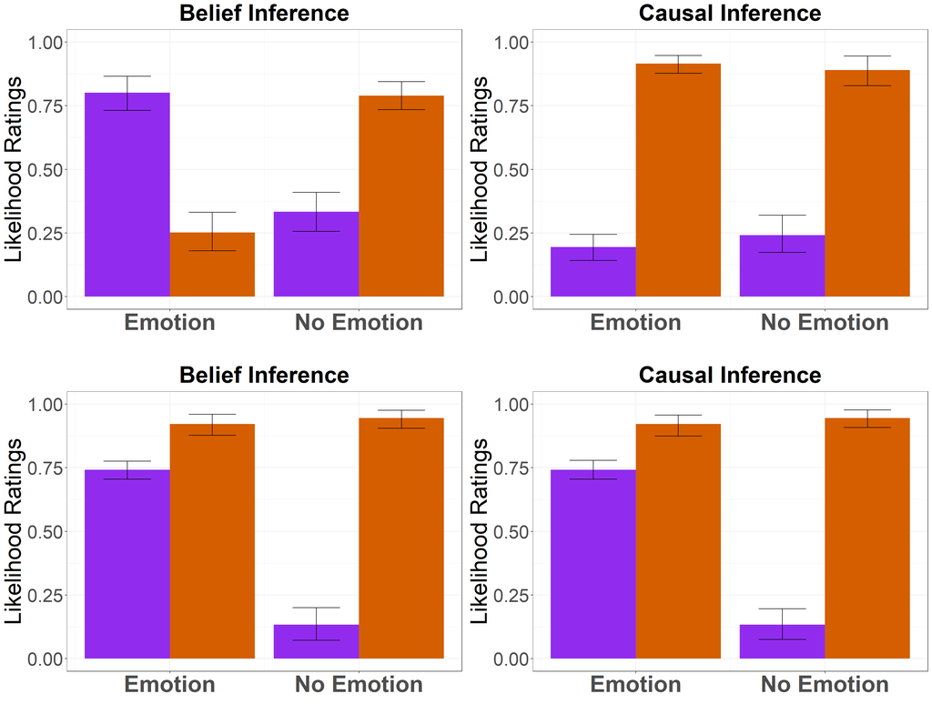

```r
library(grid)
grid.newpage()
grid.draw(rbind(cbind(ggplotGrob(plot_human_expectation+theme(legend.position="none")), ggplotGrob(plot_human_cause+theme(legend.position="none")), size = "last"),
          cbind(ggplotGrob(plot_model_expectation+theme(legend.position="none")), ggplotGrob(plot_model_cause+theme(legend.position="none")), size = "last")))
```

```r
#1300x800
```

# 6 Hypothesis Testing

## 6.1 Belief Inferences

```r
wilcox.test(exp1Norm ~ condition, ecl_dat)
```

```
##
##  Wilcoxon rank sum test with continuity correction
##
## data:  exp1Norm by condition
## W = 3309, p-value = 4.848e-12
## alternative hypothesis: true location shift is not equal to 0
```

Additionally, participants in the emotion condition were less likely to infer that the agent expected the box to turn on the red bulb ($W=444.0, p < .001$) than participants in the no-emotion condition. Participants in the no emotion condition assumed that the agent’s intended to turn on the red bulb (since there was no negative reaction to the outcome).

```r
wilcox.test(exp2Norm ~ condition, ecl_dat)
```

```
##
##  Wilcoxon rank sum test with continuity correction
##
## data:  exp2Norm by condition
## W = 444, p-value = 6.078e-14
## alternative hypothesis: true location shift is not equal to 0
```

## 6.2 Causal Inferences

As expected, participants’ ratings on the causal relationship between the box and the purple bulb did not statistically differ across conditions. Participants relied mainly on direct observations to draw causal inference in this scenario and these observations support only one hypothesis.

```r
wilcox.test(relationBlueOneNorm ~ condition, ecl_dat)
```

```
##
##  Wilcoxon rank sum test with continuity correction
##
## data:  relationBlueOneNorm by condition
## W = 1842, p-value = 0.6237
## alternative hypothesis: true location shift is not equal to 0
```

As expected, participants’ ratings on the causal relationship between the box and the red bulb did not statistically differ across conditions. Participants relied mainly on direct observations to draw causal inference in this scenario and these observations support only one hypothesis.

```r
wilcox.test(relationBlueTwoNorm ~ condition, ecl_dat)
```

```
##
##  Wilcoxon rank sum test with continuity correction
##
## data:  relationBlueTwoNorm by condition
## W = 1881.5, p-value = 0.745
## alternative hypothesis: true location shift is not equal to 0
```

## 6.3 Desire Inferences

On desire inference, participants in the emotion condition were more likely to infer that the agent desired the purple bulb to be switched on ($W=3288.0, p < .001$) than participants in the no-emotion condition. This is consistent with the belief inferences. The participants inferred that the agent intended to turn on the purple bulb in the emotion condition and conversely the red bulb in the no-emotion condition.

```r
wilcox.test(desire1Norm ~ condition, ecl_dat) # bulb1
```

```
##
##  Wilcoxon rank sum test with continuity correction
##
## data:  desire1Norm by condition
## W = 3288, p-value = 1.005e-11
## alternative hypothesis: true location shift is not equal to 0
```

```r
wilcox.test(desire2Norm ~ condition, ecl_dat) # bulb2
```

```
##
##  Wilcoxon rank sum test with continuity correction
##
## data:  desire2Norm by condition
## W = 490, p-value = 3.825e-13
## alternative hypothesis: true location shift is not equal to 0
```

This table describes the mean (and SD in brackets) of the scaled desire ratings (for turning on purple and red bulbs respectively) (between 0 and 1) for the emotion and no-emotion conditions.

```r
ecl_dat %>%
  group_by(condition) %>%
  summarise(
    desirePurple = paste0(round(mean(desire1Norm, na.rm = T),2)," (",round(sd(desire1Norm, na.rm = T),2), ")"),
    desireRed = paste0(round(mean(desire2Norm, na.rm = T),2)," (",round(sd(desire2Norm, na.rm = T),2), ")")
  )
```

| condition | desirePurple | desireRed |
| --- | --- | --- |
| emotion | 0.82 (0.25) | 0.24 (0.32) |
| no-emotion | 0.45 (0.26) | 0.74 (0.21) |

## 6.4 Knowledge Inferences

Finally, with regards to knowledge inference, participants in the emotion condition were less likely to infer that the agent was knowledgeable about the function of the box ($W=1500.5, p = 0.028$) than participants in the no-emotion condition. From the agent’s frustration, participants in the emotion condition perceived that he made a mistake and hence inferred that he is not highly knowledgeable.

```r
wilcox.test(knowledgeNorm ~ condition, ecl_dat)
```

```
##
##  Wilcoxon rank sum test with continuity correction
##
## data:  knowledgeNorm by condition
## W = 1500.5, p-value = 0.02822
## alternative hypothesis: true location shift is not equal to 0
```

This table describes the mean (and SD in brackets) of the scaled knowledge ratings (between 0 and 1) for the emotion and no-emotion conditions.

```r
ecl_dat %>%
  group_by(condition) %>%
  summarise(
    knowledge = paste0(round(mean(knowledgeNorm, na.rm = T),2)," (",round(sd(knowledgeNorm, na.rm = T),2), ")")
  )
```

| condition | knowledge |
| --- | --- |
| emotion | 0.61 (0.25) |
| no-emotion | 0.71 (0.22) |